# Workflow example:stress on cognition in rodents

# Setting-up

## Loading packages

```r
# install.packages("pacman")

pacman::p_load(tidyverse,
               here,
               devtools,
               patchwork,
               R.rsp,
               emmeans,
               metafor) #for analysis

# devtools::install_github("daniel1noble/orchaRd", force = TRUE)
library(orchaRd) #for heterogeneity, marginal R2 and orchard plots
```

## Loading data

```r
dat <- read_csv(here("Workflow example_stress on cognition","Data_stress on cognition.csv"))

str(dat)
```

```
## spec_tbl_df [92 × 21] (S3: spec_tbl_df/tbl_df/tbl/data.frame)
##  $ ES_ID               : num [1:92] 1 2 3 4 5 6 7 8 9 10 ...
##  $ Study_ID            : num [1:92] 1 1 1 2 3 4 5 5 6 6 ...
##  $ First_author        : chr [1:92] "Aghighi Bidgoli" "Aghighi Bidgoli" "Aghighi Bidgoli" "Berardo" ...
##  $ Year_published      : num [1:92] 2020 2020 2020 2016 2017 ...
##  $ Common_species      : chr [1:92] "Rat" "Rat" "Rat" "Rat" ...
##  $ Strain              : chr [1:92] "Wistar" "Wistar" "Wistar" "Wistar" ...
##  $ Sex                 : chr [1:92] "Male" "Male" "Male" "Male" ...
##  $ Age_stress_exposure : chr [1:92] "Prenatal" "Prenatal" "Prenatal" "Early postnatal" ...
##  $ Type_stress_exposure: chr [1:92] "Noise" "Noise" "Noise" "MS" ...
##  $ Stress_duration     : chr [1:92] "Intermittent" "Intermittent" "Intermittent" "Chronic" ...
##  $ Learning_vs_memory  : chr [1:92] "Learning" "Learning" "Memory" "Learning" ...
##  $ Type_assay          : chr [1:92] "Conditioning" "Conditioning" "Conditioning" "Conditioning" ...
##  $ Type_reinforcement  : chr [1:92] "Aversive" "Aversive" "Aversive" "Aversive" ...
##  $ lnRR                : num [1:92] -0.2456 -0.2554 -0.1969 0.0136 0.0756 ...
##  $ lnRRV               : num [1:92] 0.01157 0.02082 0.0031 0.02476 0.00117 ...
##  $ Mean_stress         : logi [1:92] NA NA NA NA NA NA ...
##  $ SD_stress           : logi [1:92] NA NA NA NA NA NA ...
##  $ N_stress            : logi [1:92] NA NA NA NA NA NA ...
##  $ Mean_control        : logi [1:92] NA NA NA NA NA NA ...
##  $ SD_control          : logi [1:92] NA NA NA NA NA NA ...
##  $ N_control           : logi [1:92] NA NA NA NA NA NA ...
##  - attr(*, "spec")=
##   .. cols(
##   ..   ES_ID = col_double(),
##   ..   Study_ID = col_double(),
##   ..   First_author = col_character(),
##   ..   Year_published = col_double(),
##   ..   Common_species = col_character(),
##   ..   Strain = col_character(),
##   ..   Sex = col_character(),
##   ..   Age_stress_exposure = col_character(),
##   ..   Type_stress_exposure = col_character(),
##   ..   Stress_duration = col_character(),
##   ..   Learning_vs_memory = col_character(),
##   ..   Type_assay = col_character(),
##   ..   Type_reinforcement = col_character(),
##   ..   lnRR = col_double(),
##   ..   lnRRV = col_double(),
##   ..   Mean_stress = col_logical(),
##   ..   SD_stress = col_logical(),
##   ..   N_stress = col_logical(),
##   ..   Mean_control = col_logical(),
##   ..   SD_control = col_logical(),
##   ..   N_control = col_logical()
##   .. )
##  - attr(*, "problems")=<externalptr>
```

# Calculating effect size and variance

In this case we will use lnRR, but standardised mean differences (e.g., Cohen’s D can also be used and will produce comparable results).

To quantify differences in individual performance in cognitive assays with stress, we used the logarithm of response ratio (lnRR) calculated as:
$$\ln{\text{RR}_\text{stress}} = \ln \left(
{\frac {M_\text{stress}} {M_\text{control}}}
\right)$$

Variance was calculated as:

$$\text{var}(\ln{\text{RR}_\text{stress}}) =
\frac{SD_\text{stress}^2}{N_\text{stress} M_\text{stress}^2} + \frac{SD_\text{control}^2}{N_\text{control}M_\text{control}^2}$$
Note that I have already calculated lnRR and variance previously as the data used in the meta-analysis which was bit more complicated than normal - we will calculate it using the function *escalc* in the “practice together” dataset.

# Meta-analysis

```r
mod_S0 <- rma.mv(yi = lnRR, V = lnRRV, random = list(~1|Study_ID,
                                                          ~1|ES_ID,
                                                          ~1|Strain),
                 test = "t",
                 data = dat)

#yi = effect size, V = variance, random = a list of your random effects (these will always include study ID and effect size ID)

summary(mod_S0) #global effect size
```

```
##
## Multivariate Meta-Analysis Model (k = 92; method: REML)
##
##   logLik  Deviance       AIC       BIC      AICc
## -10.7515   21.5030   29.5030   39.5464   29.9681
##
## Variance Components:
##
##             estim    sqrt  nlvls  fixed    factor
## sigma^2.1  0.0178  0.1333     30     no  Study_ID
## sigma^2.2  0.0252  0.1588     92     no     ES_ID
## sigma^2.3  0.0000  0.0000      6     no    Strain
##
## Test for Heterogeneity:
## Q(df = 91) = 792.5937, p-val < .0001
##
## Model Results:
##
## estimate      se     tval  df    pval    ci.lb    ci.ub
##  -0.1107  0.0337  -3.2808  91  0.0015  -0.1777  -0.0437  **
##
## ---
## Signif. codes:  0 '***' 0.001 '**' 0.01 '*' 0.05 '.' 0.1 ' ' 1
```

```r
i2_ml(mod_S0) #heterogeneity: The I2 informs the proportion of the variance in observed effect is due to variance in true effects rather than sampling error
```

```
##     I2_Total  I2_Study_ID     I2_ES_ID    I2_Strain
## 9.314758e+01 3.849172e+01 5.465586e+01 1.415541e-08
```

Creating an orchard plot: Checkout the vignette on how to make cool plots https://daniel1noble.github.io/orchaRd/

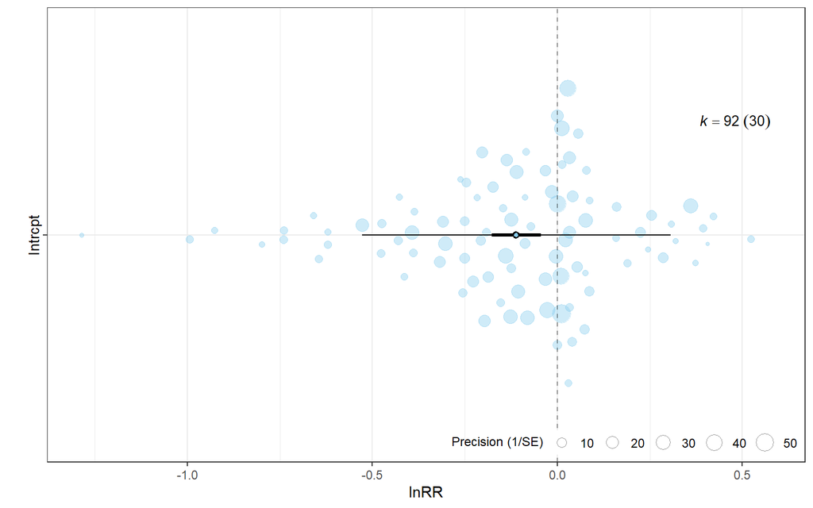

```r
orchard_plot(mod_S0, mod = "1", group = "Study_ID", data = dat, xlab = "lnRR", alpha=0.4)
```

**Fig.1** Orchard plot showing meta-analytic mean and 95% confidence interval (thick black line) and 95% prediction interval (thin black line). Individual points show observed effect sizes scaled proportionately to their precision.

# Meta-regression

Any moderator categories with k < 5 were removed.

## Type of assay

The broad category of the type of assay used to measure learning or memory.

```r
dat$Type_assay<-as.factor(dat$Type_assay)

mod_S1 <- rma.mv(yi = lnRR, V = lnRRV, mod = ~Type_assay-1, random =   list(~1|Study_ID,
                                                                                    ~1|ES_ID,
                                                                                    ~1|Strain),
                 test = "t",
                 data = dat)

summary(mod_S1)
```

```
##
## Multivariate Meta-Analysis Model (k = 92; method: REML)
##
##   logLik  Deviance       AIC       BIC      AICc
##  -5.5303   11.0606   23.0606   37.9924   24.0850
##
## Variance Components:
##
##             estim    sqrt  nlvls  fixed    factor
## sigma^2.1  0.0250  0.1582     30     no  Study_ID
## sigma^2.2  0.0156  0.1251     92     no     ES_ID
## sigma^2.3  0.0000  0.0000      6     no    Strain
##
## Test for Residual Heterogeneity:
## QE(df = 89) = 714.5938, p-val < .0001
##
## Test of Moderators (coefficients 1:3):
## F(df1 = 3, df2 = 89) = 8.0989, p-val < .0001
##
## Model Results:
##
##                         estimate      se     tval  df    pval    ci.lb    ci.ub
## Type_assayConditioning   -0.0961  0.0375  -2.5599  89  0.0122  -0.1707  -0.0215
## Type_assayHabituation    -0.4659  0.0991  -4.7012  89  <.0001  -0.6629  -0.2690
## Type_assayRecognition    -0.0773  0.0603  -1.2835  89  0.2027  -0.1971   0.0424
##
## Type_assayConditioning    *
## Type_assayHabituation   ***
## Type_assayRecognition
##
## ---
## Signif. codes:  0 '***' 0.001 '**' 0.01 '*' 0.05 '.' 0.1 ' ' 1
```

```r
r2_ml(mod_S1) #marginal R2 "variance explained by only fixed effects"
```

```
##    R2_marginal R2_conditional
##      0.1962445      1.0000000
```

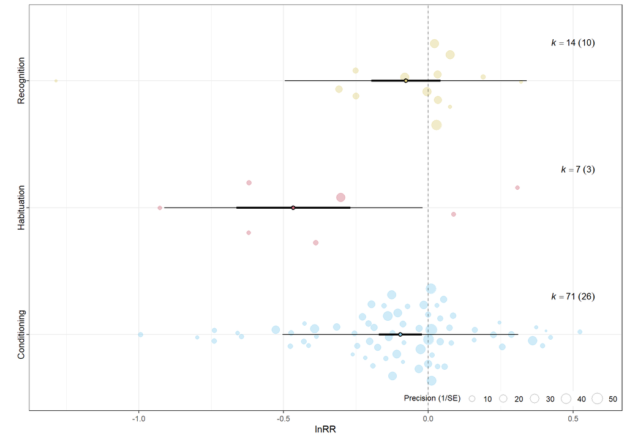

```r
orchard_plot(mod_S1, mod = "Type_assay", group = "Study_ID", data = dat, xlab = "lnRR", alpha=0.4)
```

**Fig. 2** Orchard plot showing the group-wise means of the categorical variable ‘Type_assay’ with their 95% confidence interval (thick black line) and 95% prediction interval (thin black line). Individual points show observed effect sizes scaled proportionately to their precision. k is number of effect sizes followed by the number of studies.

## Age at stress

The age when individuals were exposed to stress.

```r
mod_S2 <-rma.mv(yi = lnRR, V = lnRRV, mod = ~Age_stress_exposure-1, random = list(~1|Study_ID,
                                                                                       ~1|ES_ID,
                                                                                       ~1|Strain),
                test = "t",
                data = dat)
summary(mod_S2)
```

```
##
## Multivariate Meta-Analysis Model (k = 92; method: REML)
##
##   logLik  Deviance       AIC       BIC      AICc
##  -9.1273   18.2546   32.2546   49.5960   33.6546
##
## Variance Components:
##
##             estim    sqrt  nlvls  fixed    factor
## sigma^2.1  0.0136  0.1165     30     no  Study_ID
## sigma^2.2  0.0261  0.1617     92     no     ES_ID
## sigma^2.3  0.0000  0.0000      6     no    Strain
##
## Test for Residual Heterogeneity:
## QE(df = 88) = 647.9747, p-val < .0001
##
## Test of Moderators (coefficients 1:4):
## F(df1 = 4, df2 = 88) = 4.4687, p-val = 0.0025
##
## Model Results:
##
##                                     estimate      se     tval  df    pval
## Age_stress_exposureAdolescent         0.0063  0.1184   0.0530  88  0.9579
## Age_stress_exposureAdult             -0.2301  0.0625  -3.6839  88  0.0004
## Age_stress_exposureEarly postnatal   -0.0652  0.0440  -1.4824  88  0.1418
## Age_stress_exposurePrenatal          -0.1148  0.0792  -1.4505  88  0.1505
##                                       ci.lb    ci.ub
## Age_stress_exposureAdolescent       -0.2290   0.2415
## Age_stress_exposureAdult            -0.3542  -0.1060  ***
## Age_stress_exposureEarly postnatal  -0.1527   0.0222
## Age_stress_exposurePrenatal         -0.2721   0.0425
##
## ---
## Signif. codes:  0 '***' 0.001 '**' 0.01 '*' 0.05 '.' 0.1 ' ' 1
```

```r
r2_ml(mod_S2)
```

```
##    R2_marginal R2_conditional
##      0.1033779      1.0000000
```

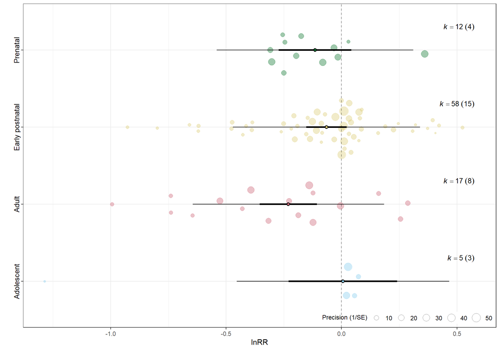

```r
orchard_plot(mod_S2, mod = "Age_stress_exposure", group ="Study_ID", data = dat, xlab = "lnRR", alpha=0.4)
```

**Fig. 3** Orchard plot showing the group-wise means of the categorical variable ‘Age_stress_exposure’ with their 95% confidence interval (thick black line) and 95% prediction interval (thin black line). Individual points show observed effect sizes scaled proportionately to their precision. k is number of effect sizes followed by the number of studies.

# Publication bias

## Funnel plot

Note that this is just an example of a funnel plot and it is best to plot it from a full-model with the moderators used in the meta-regression

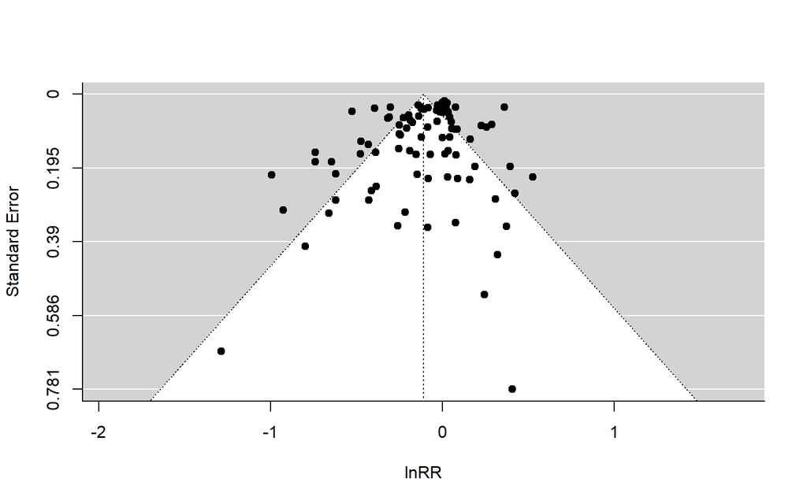

```r
funnel(mod_S0, xlab = "lnRR", ylab = "Standard Error")
```